# Homework 6 STA 206

Kevin Su

11/11/2021

# Problem 5

## A

```r
setwd("C:/Users/kevin/Downloads")
property <- read.table("property.txt")
colnames(property) <- c("Y", "X1", "X2", "X3", "X4")

Model1 <- lm(Y~X1+X2+X4+X3, data = property)
```

## B

```r
summary(Model1)
```

```
##
## Call:
## lm(formula = Y ~ X1 + X2 + X4 + X3, data = property)
##
## Residuals:
##     Min      1Q  Median      3Q     Max
## -3.1872 -0.5911 -0.0910  0.5579  2.9441
##
## Coefficients:
##               Estimate Std. Error t value Pr(>|t|)
## (Intercept)  1.220e+01  5.780e-01  21.110  < 2e-16 ***
## X1          -1.420e-01  2.134e-02  -6.655 3.89e-09 ***
## X2           2.820e-01  6.317e-02   4.464 2.75e-05 ***
## X4           7.924e-06  1.385e-06   5.722 1.98e-07 ***
## X3           6.193e-01  1.087e+00   0.570     0.57
## ---
## Signif. codes:  0 '***' 0.001 '**' 0.01 '*' 0.05 '.' 0.1 ' ' 1
##
## Residual standard error: 1.137 on 76 degrees of freedom
## Multiple R-squared:  0.5847, Adjusted R-squared:  0.5629
## F-statistic: 26.76 on 4 and 76 DF,  p-value: 7.272e-14
```

```r
anova(Model1)
```

```
## Analysis of Variance Table
##
## Response: Y
##           Df Sum Sq Mean Sq F value    Pr(>F)
## X1         1 14.819  14.819 11.4649  0.001125 **
## X2         1 72.802  72.802 56.3262 9.699e-11 ***
## X4         1 50.287  50.287 38.9062 2.306e-08 ***
## X3         1  0.420   0.420  0.3248  0.570446
## Residuals 76 98.231   1.293
## ---
## Signif. codes:  0 '***' 0.001 '**' 0.01 '*' 0.05 '.' 0.1 ' ' 1
```

```r
PartRSqX3 <- anova(Model1)$`Sum Sq`[4]/sum(anova(Model1)$`Sum Sq`[c(4,5)])
PartRSqX3
```

```
## [1] 0.004254889
```

```r
PartcorrX3 <- sqrt(PartRSqX3) #sign is positive
PartcorrX3
```

```
## [1] 0.06522951
```

The fitted regression coefficient of X3 is 0.6193. The coefficient of partial determination R-squared(Y-3|124) is 0.420/(0.420 + 98.231) = 0.00426. The partial correlation is the signed square root of this value is 0.06523. The coefficient of partial determination measures the proportion of remaining SSE that is reduced by adding the new variable.

## C

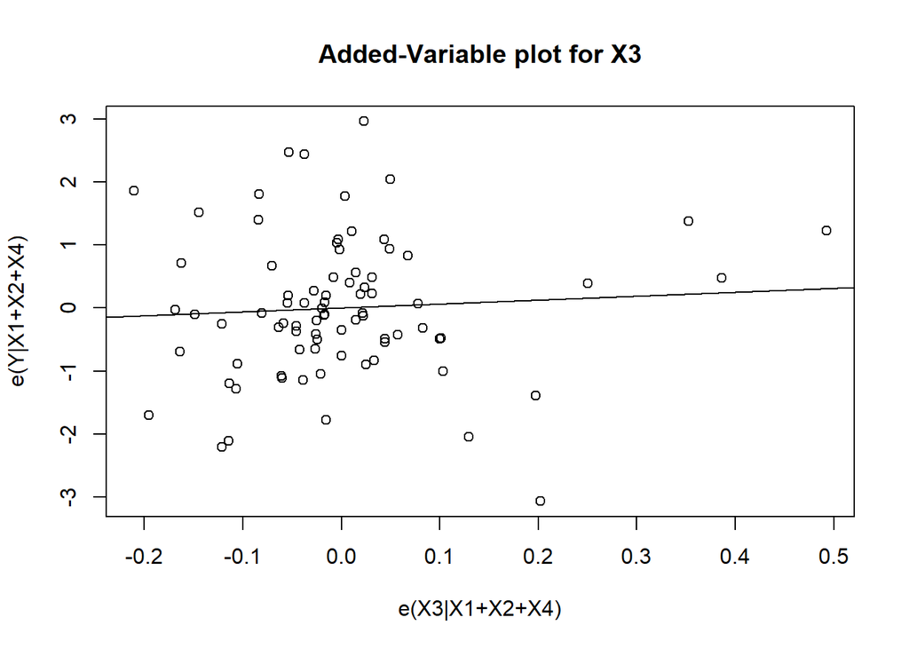

```r
eY.124 <- lm(Y~X1+X2+X4, data = property)$residuals
e3.124 <- lm(X3~X1+X2+X4, data = property)$residuals
av3 = lm(eY.124~e3.124)

plot(e3.124, eY.124, ylab = "e(Y|X1+X2+X4)", xlab = "e(X3|X1+X2+X4)", main = "Added-Variable plot for X3")
abline(av3)
```

We can see here X3 is not very useful in explaining additional variation in Y on top of X1, X2, and X4.

## D

```r
summary(Model1)
```

```
##
## Call:
## lm(formula = Y ~ X1 + X2 + X4 + X3, data = property)
##
## Residuals:
##     Min      1Q  Median      3Q     Max
## -3.1872 -0.5911 -0.0910  0.5579  2.9441
##
## Coefficients:
##               Estimate Std. Error t value Pr(>|t|)
## (Intercept)  1.220e+01  5.780e-01  21.110  < 2e-16 ***
## X1          -1.420e-01  2.134e-02  -6.655 3.89e-09 ***
## X2           2.820e-01  6.317e-02   4.464 2.75e-05 ***
## X4           7.924e-06  1.385e-06   5.722 1.98e-07 ***
## X3           6.193e-01  1.087e+00   0.570     0.57
## ---
## Signif. codes:  0 '***' 0.001 '**' 0.01 '*' 0.05 '.' 0.1 ' ' 1
##
## Residual standard error: 1.137 on 76 degrees of freedom
## Multiple R-squared:  0.5847, Adjusted R-squared:  0.5629
## F-statistic: 26.76 on 4 and 76 DF,  p-value: 7.272e-14
```

```r
summary(av3)
```

```
##
## Call:
## lm(formula = eY.124 ~ e3.124)
##
## Residuals:
##     Min      1Q  Median      3Q     Max
## -3.1872 -0.5911 -0.0910  0.5579  2.9441
##
## Coefficients:
##               Estimate Std. Error t value Pr(>|t|)
## (Intercept) -1.039e-16  1.239e-01   0.000    1.000
## e3.124       6.193e-01  1.066e+00   0.581    0.563
##
## Residual standard error: 1.115 on 79 degrees of freedom
## Multiple R-squared:  0.004255,   Adjusted R-squared:  -0.008349
## F-statistic: 0.3376 on 1 and 79 DF,  p-value: 0.5629
```

```r
anova(av3)
```

```
## Analysis of Variance Table
##
## Response: eY.124
##           Df Sum Sq Mean Sq F value Pr(>F)
## e3.124     1  0.420 0.41975  0.3376 0.5629
## Residuals 79 98.231 1.24343
```

```r
anova(Model1)
```

```
## Analysis of Variance Table
##
## Response: Y
##           Df Sum Sq Mean Sq F value    Pr(>F)
## X1         1 14.819  14.819 11.4649  0.001125 **
## X2         1 72.802  72.802 56.3262 9.699e-11 ***
## X4         1 50.287  50.287 38.9062 2.306e-08 ***
## X3         1  0.420   0.420  0.3248  0.570446
## Residuals 76 98.231   1.293
## ---
## Signif. codes:  0 '***' 0.001 '**' 0.01 '*' 0.05 '.' 0.1 ' ' 1
```

The slope from regressing the residuals of Y in the reduced model to the residuals of X3 regressed on X1, X2, and X4 yield the same fitted regression coefficient from Model1.

```r
anova(av3)
```

```
## Analysis of Variance Table
##
## Response: eY.124
##           Df Sum Sq Mean Sq F value Pr(>F)
## e3.124     1  0.420 0.41975  0.3376 0.5629
## Residuals 79 98.231 1.24343
```

```r
anova(Model1)
```

```
## Analysis of Variance Table
##
## Response: Y
##           Df Sum Sq Mean Sq F value    Pr(>F)
## X1         1 14.819  14.819 11.4649  0.001125 **
## X2         1 72.802  72.802 56.3262 9.699e-11 ***
## X4         1 50.287  50.287 38.9062 2.306e-08 ***
## X3         1  0.420   0.420  0.3248  0.570446
## Residuals 76 98.231   1.293
## ---
## Signif. codes:  0 '***' 0.001 '**' 0.01 '*' 0.05 '.' 0.1 ' ' 1
```

The regression sum of squares from part D is identical to the extra sum of squares from the R output of model 1.

## F

```r
cor(eY.124, e3.124)
```

```
## [1] 0.06522951
```

```r
PartcorrX3
```

```
## [1] 0.06522951
```

```r
cor(eY.124,e3.124)^2
```

```
## [1] 0.004254889
```

```r
PartRSqX3
```

```
## [1] 0.004254889
```

The correlation coefficient between the two sets of residuals is identical to the partial correlation from part B at 0.06523. R-squared is the same as the partial coefficient of determination from part B as well at 0.004255.

## G

```r
summary(lm(property$Y~e3.124))
```

```
##
## Call:
## lm(formula = property$Y ~ e3.124)
##
## Residuals:
##     Min      1Q  Median      3Q     Max
## -4.7641 -1.1392 -0.1056  1.1221  4.1630
##
## Coefficients:
##             Estimate Std. Error t value Pr(>|t|)
## (Intercept)  15.1389     0.1921  78.807   <2e-16 ***
## e3.124        0.6193     1.6528   0.375    0.709
## ---
## Signif. codes:  0 '***' 0.001 '**' 0.01 '*' 0.05 '.' 0.1 ' ' 1
##
## Residual standard error: 1.729 on 79 degrees of freedom
## Multiple R-squared:  0.001774,   Adjusted R-squared:  -0.01086
## F-statistic: 0.1404 on 1 and 79 DF,  p-value: 0.7089
```

```r
summary(Model1)
```

```
##
## Call:
## lm(formula = Y ~ X1 + X2 + X4 + X3, data = property)
##
## Residuals:
##     Min      1Q  Median      3Q     Max
## -3.1872 -0.5911 -0.0910  0.5579  2.9441
##
## Coefficients:
##               Estimate Std. Error t value Pr(>|t|)
## (Intercept)  1.220e+01  5.780e-01  21.110  < 2e-16 ***
## X1          -1.420e-01  2.134e-02  -6.655 3.89e-09 ***
## X2           2.820e-01  6.317e-02   4.464 2.75e-05 ***
## X4           7.924e-06  1.385e-06   5.722 1.98e-07 ***
## X3           6.193e-01  1.087e+00   0.570     0.57
## ---
## Signif. codes:  0 '***' 0.001 '**' 0.01 '*' 0.05 '.' 0.1 ' ' 1
##
## Residual standard error: 1.137 on 76 degrees of freedom
## Multiple R-squared:  0.5847, Adjusted R-squared:  0.5629
## F-statistic: 26.76 on 4 and 76 DF,  p-value: 7.272e-14
```

The fitted regression slope for regressing Y to the residuals of the regression of X3 on X1,2,4 is identical to the slope for X3 in Model1. The residuals from regressing X3 on X1,2,4 will leave the variation in X3 unexplained by X1,2,4. As such, this will be reflected in regressing Y to the variation in X3.

# Problem 6

## A

```r
sapply(property, mean)
```

```
##            Y           X1           X2           X3           X4
## 1.513889e+01 7.864198e+00 9.688148e+00 8.098765e-02 1.606333e+05
```

```r
sapply(property, sd)
```

```
##            Y           X1           X2           X3           X4
## 1.719584e+00 6.632784e+00 2.583169e+00 1.345512e-01 1.090990e+05
```

```r
propertyT <- property
for (i in 2:5)
{
  propertyT[,i] = ((property[,i]-mean(property[,i]))/sd(property[,i]))/sqrt((length(property[,i])) - 1)
}

sapply(propertyT, mean)
```

```
##             Y            X1            X2            X3            X4
##  1.513889e+01 -3.453887e-18  6.909112e-18 -7.028742e-18  1.511830e-17
```

```r
sapply(propertyT, sd)
```

```
##         Y        X1        X2        X3        X4
## 1.7195839 0.1118034 0.1118034 0.1118034 0.1118034
```

The sample means of the transformed variables are 0 (though they have some infinitesimal values due to floating point errors). The sample standard deviations of the transformed variables are 1/sqrt(80).

## B

```r
Model2 <- lm(Y~X1+X2+X4+X3, data = propertyT)
summary(Model2)
```

```
##
## Call:
## lm(formula = Y ~ X1 + X2 + X4 + X3, data = propertyT)
##
## Residuals:
##     Min      1Q  Median      3Q     Max
## -3.1872 -0.5911 -0.0910  0.5579  2.9441
##
## Coefficients:
##             Estimate Std. Error t value Pr(>|t|)
## (Intercept)  15.1389     0.1263 119.845  < 2e-16 ***
## X1           -8.4262     1.2662  -6.655 3.89e-09 ***
## X2            6.5159     1.4596   4.464 2.75e-05 ***
## X4            7.7326     1.3513   5.722 1.98e-07 ***
## X3            0.7454     1.3079   0.570     0.57
## ---
## Signif. codes:  0 '***' 0.001 '**' 0.01 '*' 0.05 '.' 0.1 ' ' 1
##
## Residual standard error: 1.137 on 76 degrees of freedom
## Multiple R-squared:  0.5847, Adjusted R-squared:  0.5629
## F-statistic: 26.76 on 4 and 76 DF,  p-value: 7.272e-14
```

The model equation for the standard first-order regression model with all four transformed X variables is Y = 15.1389 - 8.4262X1 + 6.5159X2 + 0.7454X3 + 7.7326X4, with the Xi’s being transformed. The fitted regression intercept at 15.1389 differs from the intercept from Model1 in that the transformed model has the intercept at the mean of Y.

## C

```r
anova(Model2)
```

```
## Analysis of Variance Table
##
## Response: Y
##           Df Sum Sq Mean Sq F value    Pr(>F)
## X1         1 14.819  14.819 11.4649  0.001125 **
## X2         1 72.802  72.802 56.3262 9.699e-11 ***
## X4         1 50.287  50.287 38.9062 2.306e-08 ***
## X3         1  0.420   0.420  0.3248  0.570446
## Residuals 76 98.231   1.293
## ---
## Signif. codes:  0 '***' 0.001 '**' 0.01 '*' 0.05 '.' 0.1 ' ' 1
```

```r
anova(Model1)
```

```
## Analysis of Variance Table
##
## Response: Y
##           Df Sum Sq Mean Sq F value    Pr(>F)
## X1         1 14.819  14.819 11.4649  0.001125 **
## X2         1 72.802  72.802 56.3262 9.699e-11 ***
## X4         1 50.287  50.287 38.9062 2.306e-08 ***
## X3         1  0.420   0.420  0.3248  0.570446
## Residuals 76 98.231   1.293
## ---
## Signif. codes:  0 '***' 0.001 '**' 0.01 '*' 0.05 '.' 0.1 ' ' 1
```

We find that the SST, SSE, and SSR under the standardized model is identical to those from the original model.

## D

```r
summary(Model2)
```

```
##
## Call:
## lm(formula = Y ~ X1 + X2 + X4 + X3, data = propertyT)
##
## Residuals:
##     Min      1Q  Median      3Q     Max
## -3.1872 -0.5911 -0.0910  0.5579  2.9441
##
## Coefficients:
##             Estimate Std. Error t value Pr(>|t|)
## (Intercept)  15.1389     0.1263 119.845  < 2e-16 ***
## X1           -8.4262     1.2662  -6.655 3.89e-09 ***
## X2            6.5159     1.4596   4.464 2.75e-05 ***
## X4            7.7326     1.3513   5.722 1.98e-07 ***
## X3            0.7454     1.3079   0.570     0.57
## ---
## Signif. codes:  0 '***' 0.001 '**' 0.01 '*' 0.05 '.' 0.1 ' ' 1
##
## Residual standard error: 1.137 on 76 degrees of freedom
## Multiple R-squared:  0.5847, Adjusted R-squared:  0.5629
## F-statistic: 26.76 on 4 and 76 DF,  p-value: 7.272e-14
```

```r
summary(Model1)
```

```
##
## Call:
## lm(formula = Y ~ X1 + X2 + X4 + X3, data = property)
##
## Residuals:
##     Min      1Q  Median      3Q     Max
## -3.1872 -0.5911 -0.0910  0.5579  2.9441
##
## Coefficients:
##               Estimate Std. Error t value Pr(>|t|)
## (Intercept)  1.220e+01  5.780e-01  21.110  < 2e-16 ***
## X1          -1.420e-01  2.134e-02  -6.655 3.89e-09 ***
## X2           2.820e-01  6.317e-02   4.464 2.75e-05 ***
## X4           7.924e-06  1.385e-06   5.722 1.98e-07 ***
## X3           6.193e-01  1.087e+00   0.570     0.57
## ---
## Signif. codes:  0 '***' 0.001 '**' 0.01 '*' 0.05 '.' 0.1 ' ' 1
##
## Residual standard error: 1.137 on 76 degrees of freedom
## Multiple R-squared:  0.5847, Adjusted R-squared:  0.5629
## F-statistic: 26.76 on 4 and 76 DF,  p-value: 7.272e-14
```

We also find that the R-squared and R-squared adjusted are identical to that of the original model (it should follow that this is obviously the case considering SST/SSE/SSR remain identical).

# Problem 7

## A

```r
solve(cor(property[,2:5])) #Rxx inverse
```

```
##            X1         X2         X3         X4
## X1  1.2403482 -0.2870567  0.2244927 -0.2495354
## X2 -0.2870567  1.6482246  0.6092380 -0.6926391
## X3  0.2244927  0.6092380  1.3235525 -0.4399669
## X4 -0.2495354 -0.6926391 -0.4399669  1.4127219
```

```r
summary(lm(X1~X2+X4+X3, data = property))$r.squared
```

```
## [1] 0.1937747
```

```r
summary(lm(X2~X1+X4+X3, data = property))$r.squared
```

```
## [1] 0.3932866
```

```r
summary(lm(X4~X1+X2+X3, data = property))$r.squared
```

```
## [1] 0.2921466
```

```r
summary(lm(X3~X1+X2+X4, data = property))$r.squared
```

```
## [1] 0.2444576
```

```r
1/(1-summary(lm(X1~X2+X4+X3, data = property))$r.squared) #VIF X1
```

```
## [1] 1.240348
```

```r
1/(1-summary(lm(X2~X1+X4+X3, data = property))$r.squared) #VIF X2
```

```
## [1] 1.648225
```

```r
1/(1-summary(lm(X4~X1+X2+X3, data = property))$r.squared) #VIF X4
```

```
## [1] 1.412722
```

```r
1/(1-summary(lm(X3~X1+X2+X4, data = property))$r.squared) #VIF X3
```

```
## [1] 1.323552
```

## B

```r
Model3 <- lm(Y~X4, data = property)
Model4 <- lm(Y~X3+X4, data = property)

summary(Model3)
```

```
##
## Call:
## lm(formula = Y ~ X4, data = property)
##
## Residuals:
##     Min      1Q  Median      3Q     Max
## -4.1390 -0.7930  0.2890  0.9653  3.4415
##
## Coefficients:
##              Estimate Std. Error t value Pr(>|t|)
## (Intercept) 1.378e+01  2.903e-01  47.482  < 2e-16 ***
## X4          8.437e-06  1.498e-06   5.632 2.63e-07 ***
## ---
## Signif. codes:  0 '***' 0.001 '**' 0.01 '*' 0.05 '.' 0.1 ' ' 1
##
## Residual standard error: 1.462 on 79 degrees of freedom
## Multiple R-squared:  0.2865, Adjusted R-squared:  0.2775
## F-statistic: 31.72 on 1 and 79 DF,  p-value: 2.628e-07
```

```r
summary(Model4)
```

```
##
## Call:
## lm(formula = Y ~ X3 + X4, data = property)
##
## Residuals:
##     Min      1Q  Median      3Q     Max
## -4.1886 -0.7879  0.3140  0.9820  3.4021
##
## Coefficients:
##              Estimate Std. Error t value Pr(>|t|)
## (Intercept) 1.376e+01  3.027e-01  45.469  < 2e-16 ***
## X3          3.007e-01  1.226e+00   0.245    0.807
## X4          8.407e-06  1.512e-06   5.561 3.63e-07 ***
## ---
## Signif. codes:  0 '***' 0.001 '**' 0.01 '*' 0.05 '.' 0.1 ' ' 1
##
## Residual standard error: 1.47 on 78 degrees of freedom
## Multiple R-squared:  0.2871, Adjusted R-squared:  0.2688
## F-statistic:  15.7 on 2 and 78 DF,  p-value: 1.859e-06
```

```r
anova(Model3)
```

```
## Analysis of Variance Table
##
## Response: Y
##           Df  Sum Sq Mean Sq F value    Pr(>F)
## X4         1  67.775  67.775  31.723 2.628e-07 ***
## Residuals 79 168.782   2.136
## ---
## Signif. codes:  0 '***' 0.001 '**' 0.01 '*' 0.05 '.' 0.1 ' ' 1
```

```r
anova(Model4)
```

```
## Analysis of Variance Table
##
## Response: Y
##           Df  Sum Sq Mean Sq F value    Pr(>F)
## X3         1   1.047   1.047  0.4842    0.4886
## X4         1  66.858  66.858 30.9213 3.626e-07 ***
## Residuals 78 168.652   2.162
## ---
## Signif. codes:  0 '***' 0.001 '**' 0.01 '*' 0.05 '.' 0.1 ' ' 1
```

The estimated regression coefficients of X4 in these two models are not too different from each other. The SSR for X4 in these two models also does not differ by much between each other. This is likely because X3 is not a good predictor of Y, so does not change the remaining residual by much.

## C

```r
Model5 <- lm(Y~X2, data = property)
Model6 <- lm(Y~X4+X2, data = property)

summary(Model5)
```

```
##
## Call:
## lm(formula = Y ~ X2, data = property)
##
## Residuals:
##     Min      1Q  Median      3Q     Max
## -4.5733 -0.9093 -0.1559  0.8290  4.7607
##
## Coefficients:
##             Estimate Std. Error t value Pr(>|t|)
## (Intercept) 12.47026    0.68337   18.25  < 2e-16 ***
## X2           0.27545    0.06818    4.04 0.000123 ***
## ---
## Signif. codes:  0 '***' 0.001 '**' 0.01 '*' 0.05 '.' 0.1 ' ' 1
##
## Residual standard error: 1.575 on 79 degrees of freedom
## Multiple R-squared:  0.1712, Adjusted R-squared:  0.1607
## F-statistic: 16.32 on 1 and 79 DF,  p-value: 0.0001231
```

```r
summary(Model6)
```

```
##
## Call:
## lm(formula = Y ~ X4 + X2, data = property)
##
## Residuals:
##     Min      1Q  Median      3Q     Max
## -4.1949 -0.8982  0.2719  1.0263  3.9098
##
## Coefficients:
##              Estimate Std. Error t value Pr(>|t|)
## (Intercept) 1.261e+01  6.211e-01  20.296  < 2e-16 ***
## X4          6.903e-06  1.632e-06   4.229 6.34e-05 ***
## X2          1.470e-01  6.895e-02   2.132   0.0362 *
## ---
## Signif. codes:  0 '***' 0.001 '**' 0.01 '*' 0.05 '.' 0.1 ' ' 1
##
## Residual standard error: 1.43 on 78 degrees of freedom
## Multiple R-squared:  0.3258, Adjusted R-squared:  0.3085
## F-statistic: 18.84 on 2 and 78 DF,  p-value: 2.105e-07
```

```r
anova(Model5)
```

```
## Analysis of Variance Table
##
## Response: Y
##           Df  Sum Sq Mean Sq F value    Pr(>F)
## X2         1  40.503  40.503  16.321 0.0001231 ***
## Residuals 79 196.054   2.482
## ---
## Signif. codes:  0 '***' 0.001 '**' 0.01 '*' 0.05 '.' 0.1 ' ' 1
```

```r
anova(Model6)
```

```
## Analysis of Variance Table
##
## Response: Y
##           Df  Sum Sq Mean Sq F value    Pr(>F)
## X4         1  67.775  67.775 33.1457 1.611e-07 ***
## X2         1   9.291   9.291  4.5438   0.03619 *
## Residuals 78 159.491   2.045
## ---
## Signif. codes:  0 '***' 0.001 '**' 0.01 '*' 0.05 '.' 0.1 ' ' 1
```

The regression coefficient for X2 in the larger model is much lower than that of X2 in the smaller model. SSR(2) was 40.5 while SSR(2|4) is only 9.29 due to effects from multicollinearity. X4 explains much of the variance that X2 does so adding X2 adds a much smaller amount of interpretive value to a model already containing X4.

# Problem 8

## A

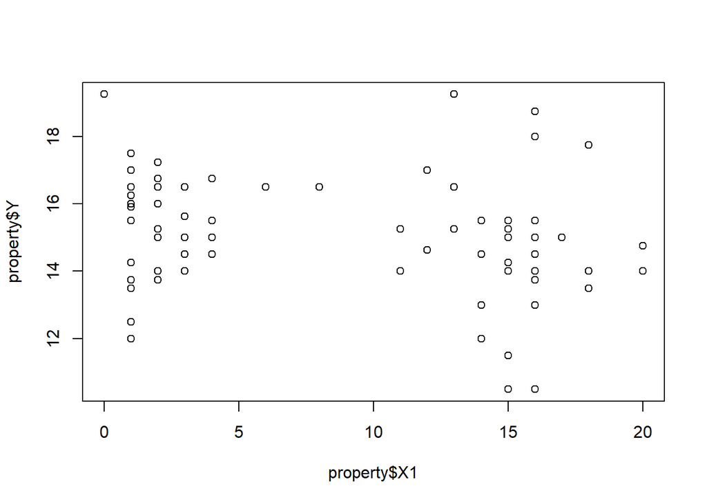

```r
plot(property$X1, property$Y)
```

## B

```r
propertyC = property

propertyC[,2] = as.numeric(scale(propertyC[,2], scale = F))

Model7 = lm(Y~X1+X2+X4+I(X1^2), data = propertyC)
summary(Model7)
```

```
##
## Call:
## lm(formula = Y ~ X1 + X2 + X4 + I(X1^2), data = propertyC)
##
## Residuals:
##      Min       1Q   Median       3Q      Max
## -2.89596 -0.62547 -0.08907  0.62793  2.68309
##
## Coefficients:
##               Estimate Std. Error t value Pr(>|t|)
## (Intercept)  1.019e+01  6.709e-01  15.188  < 2e-16 ***
## X1          -1.818e-01  2.551e-02  -7.125 5.10e-10 ***
## X2           3.140e-01  5.880e-02   5.340 9.33e-07 ***
## X4           8.046e-06  1.267e-06   6.351 1.42e-08 ***
## I(X1^2)      1.415e-02  5.821e-03   2.431   0.0174 *
## ---
## Signif. codes:  0 '***' 0.001 '**' 0.01 '*' 0.05 '.' 0.1 ' ' 1
##
## Residual standard error: 1.097 on 76 degrees of freedom
## Multiple R-squared:  0.6131, Adjusted R-squared:  0.5927
## F-statistic:  30.1 on 4 and 76 DF,  p-value: 5.203e-15
```

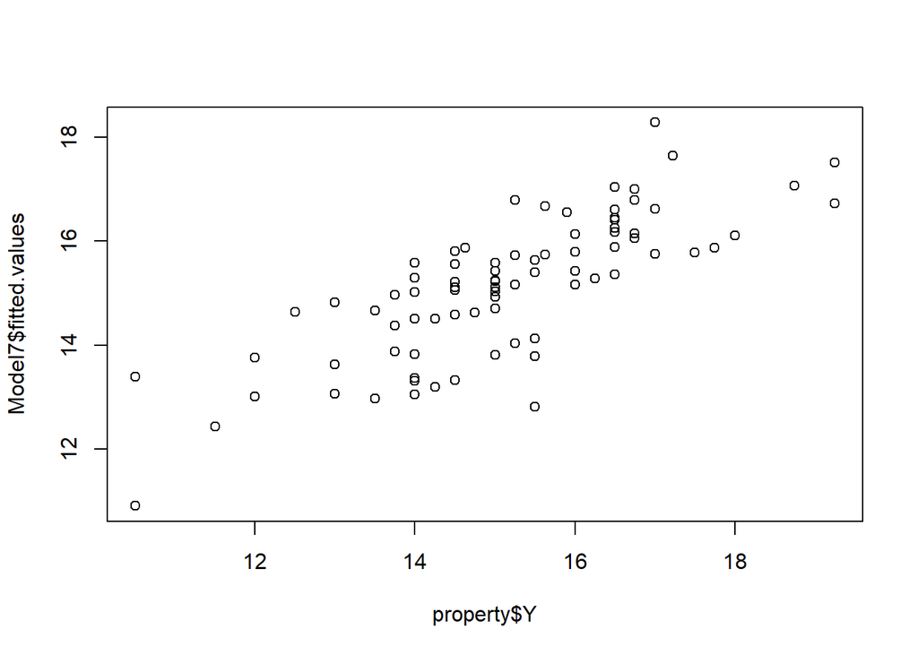

```r
plot(property$Y, Model7$fitted.values)
```

Y = 10.189 - 0.1817X1 + .314X2 + 0.000008046 X4 + 0.01415(X1^2)

The model seems to provide a reasonably good fit of the data.

## C

R-squared and R-squared adjusted of this model is higher than Model 2 from Homework 5. (about 0.03 higher for this model).

## D

```r
summary(Model7)
```

```
##
## Call:
## lm(formula = Y ~ X1 + X2 + X4 + I(X1^2), data = propertyC)
##
## Residuals:
##      Min       1Q   Median       3Q      Max
## -2.89596 -0.62547 -0.08907  0.62793  2.68309
##
## Coefficients:
##               Estimate Std. Error t value Pr(>|t|)
## (Intercept)  1.019e+01  6.709e-01  15.188  < 2e-16 ***
## X1          -1.818e-01  2.551e-02  -7.125 5.10e-10 ***
## X2           3.140e-01  5.880e-02   5.340 9.33e-07 ***
## X4           8.046e-06  1.267e-06   6.351 1.42e-08 ***
## I(X1^2)      1.415e-02  5.821e-03   2.431   0.0174 *
## ---
## Signif. codes:  0 '***' 0.001 '**' 0.01 '*' 0.05 '.' 0.1 ' ' 1
##
## Residual standard error: 1.097 on 76 degrees of freedom
## Multiple R-squared:  0.6131, Adjusted R-squared:  0.5927
## F-statistic:  30.1 on 4 and 76 DF,  p-value: 5.203e-15
```

H0: BHat associated with I(X1^2) = 0 HA: BHat associated with I(X1^2) != 0

Using T-test, we will reject null if |T| > |T(.975, df = 76)| = 1.9917.

As t = 2.431, we reject the null and the quadratic term is kept in the model as it may be useful.

## E

```r
newobs <- data.frame(X1 = 4, X2 = 10,  X4 = 80000)
predict.lm(Model7, newobs, interval = "predict", level = 0.99)
```

```
##        fit      lwr      upr
## 1 13.47259 10.47873 16.46645
```